# The Problem of Model Selection

## The Problem of Model Selection

[figure not shown]

A given data set can conceivably have been generated from uncountably many models. Identifying the true model is like finding a piece of hay in a haystack. Said another way, the model space is massive and the criterion for what constitutes the "best" model is ill-defined.

## The Problem of Model Selection

**Best strategy**: Use domain knowledge to constrain the model space and/or build models that help you answer specific scientific questions.

**Another common strategy:**

1. Pick a criterion for "best".
2. Decide how to explore the model space.
3. Select "best" model in search area.

**Tread Carefully!!!** The second strategy can lead to myopic analysis, overconfidence, and wrong-headed conclusions.

## What do we mean by "best"?

While we'd like to find the "true" model, in practice we just hope we're doing a good job at:

1. Prediction
2. Description

## Synthetic example

How smooth should our model be?

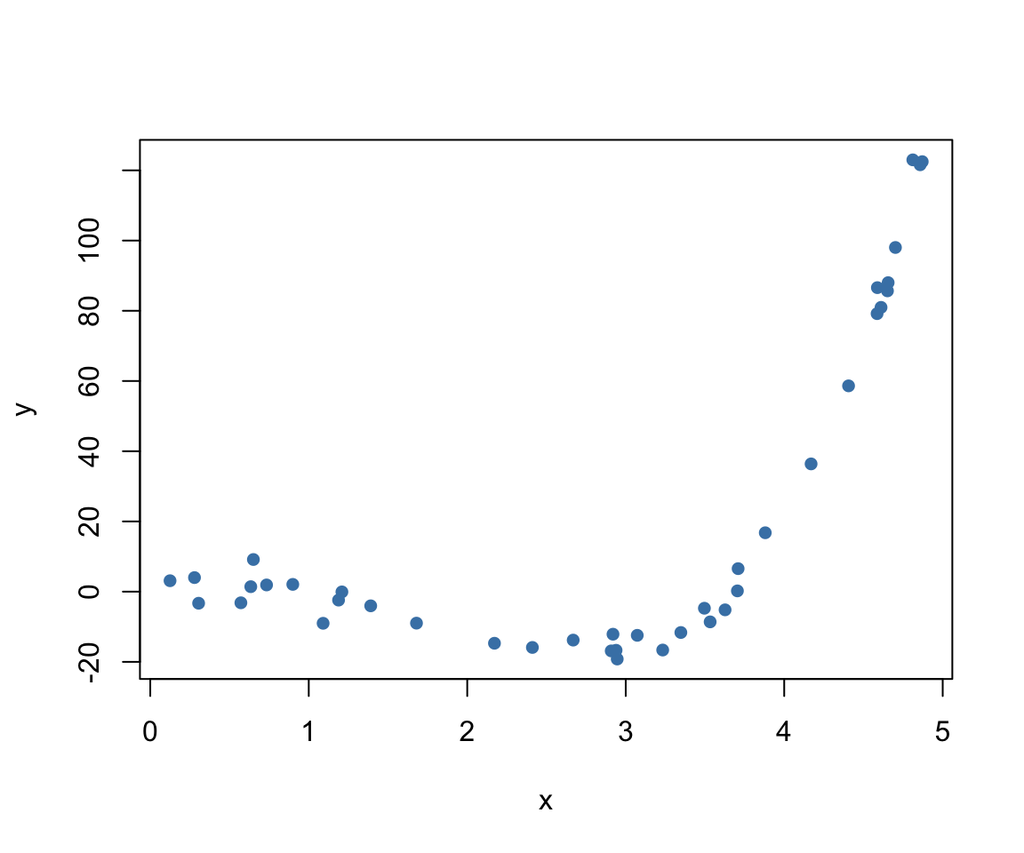

## Four candidates

```r
m1 <- lm(y ~ x)
m2 <- lm(y ~ x + I(x^2))
m3 <- lm(y ~ x + I(x^2) + I(x^3))
m4 <- lm(y ~ x + I(x^2) + I(x^3) + I(x^4))
```

We can add *polynomial* terms to account for non-linear trends.

## Four candidates

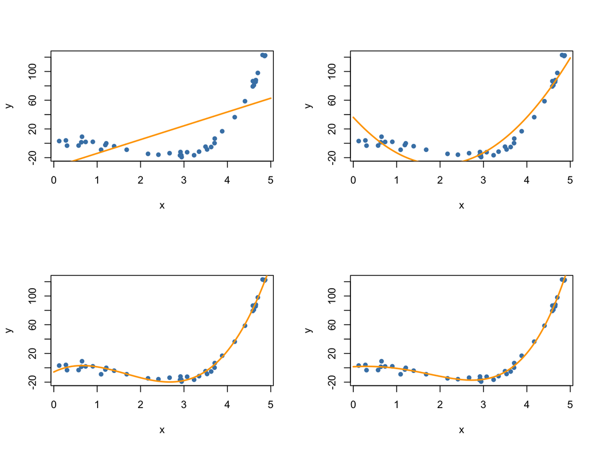

## \(R^2\)

One way to quantify the explanatory power of a model.

\[ R^2 = \frac{SS_{reg}}{SS_{tot}} \]

This captures the proportion of variability in the \(y\) explained by our regression model.

## Comparing \(R^2\)

```r
c(summary(m1)$r.squared,
  summary(m2)$r.squared,
  summary(m3)$r.squared,
  summary(m4)$r.squared)
```

```
## [1] 0.439 0.919 0.992 0.994
```

The observed data is best explained by the quartic model. So that's the best model, right?

## The BEST model!

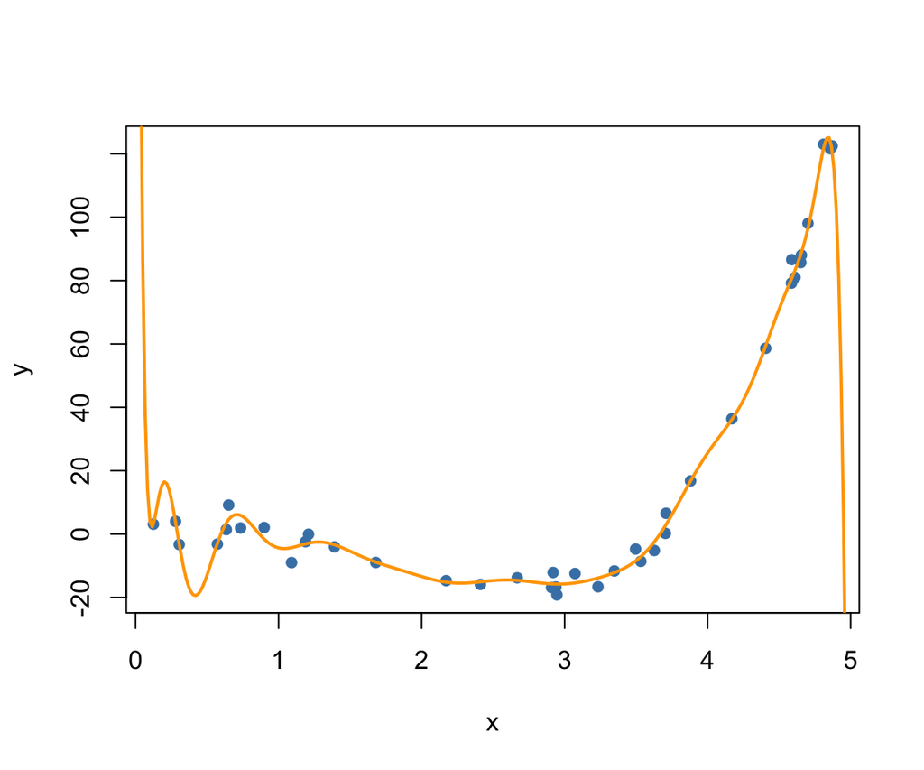

## The BEST model!

```r
mBEST <- lm(y ~ poly(x, 20))
c(summary(m1)$r.squared,
  summary(m2)$r.squared,
  summary(m3)$r.squared,
  summary(m4)$r.squared,
  summary(mBEST)$r.squared)
```

```
## [1] 0.439 0.919 0.992 0.994 0.997
```

But surely that's not the best model…

## Three Criteria

1. \(R^2\)
2. \(R^2_{adj}\)
3. p-values

There are many others (\(AIC\), \(BIC\), \(AIC_C\), …).

## \(R^2_{adj}\)

A measure of explanatory power of model:

\[ R^2 = \frac{SS_{reg}}{SS_{tot}} = 1 - \frac{SS_{res}}{SS_{tot}} \]

But it only goes up with added predictors, therefore we add a penalty.

\[ R^2_{adj} = 1 - \frac{SS_{res}/(n - (p + 1))}{SS_{tot}/(n - 1)} \]

## \(R^2\) vs. \(R^2_{adj}\)

```r
summary(mBEST)$r.squared
```

```
## [1] 0.997
```

```r
summary(mBEST)$adj.r.squared
```

```
## [1] 0.994
```

```r
set.seed(213)
poverty <- read.delim("../poverty.txt", header = TRUE)
m1 <- lm(Poverty ~ Graduates, data = poverty)
summary(m1)
poverty$Noise <- rnorm(nrow(poverty))
m2 <- lm(Poverty ~ Graduates + Noise, data = poverty)
summary(m2)
```